# Tratamiento datos COVID-19 México 16/04/2020

Viacheslav Shalisko

16/4/2020

### Datos fuente

datos abiertos SSA https://www.gob.mx/salud/documentos/datos-abiertos-152127

### Fuentes auxiliares

Diccionarios de datos SSA https://www.gob.mx/salud/documentos/datos-abiertos-152127 y Catálogo Único de Claves de Áreas Geoestadísticas Estatales, Municipales y Localidades de INEGI https://www.inegi.org.mx/app/ageeml/

## Total de casos positivos

### Total de casos registrados para 16 de abril del 2020: 6297; aumento: 450.

## Resumen de registros positivos por estado

Tabla. Casos confirmados por estado para 16 de abril del 2020

| ID | Estado | Total de casos confirmados | Casos para ayer | Aumento de casos | Casos por 100k habitantes |
| --- | --- | --- | --- | --- | --- |
| 1 | AGUASCALIENTES | 71 | 65 | 6 | 6.0 |
| 2 | BAJA CALIFORNIA | 504 | 463 | 41 | 16.0 |
| 3 | BAJA CALIFORNIA SUR | 166 | 165 | 1 | 26.1 |
| 4 | CAMPECHE | 28 | 28 | 0 | 3.4 |
| 7 | CHIAPAS | 55 | 49 | 6 | 1.1 |
| 8 | CHIHUAHUA | 107 | 84 | 23 | 3.1 |
| 9 | CIUDAD DE MÉXICO | 1592 | 1480 | 112 | 18.0 |
| 5 | COAHUILA DE ZARAGOZA | 220 | 199 | 21 | 8.0 |
| 6 | COLIMA | 8 | 8 | 0 | 1.2 |
| 10 | DURANGO | 18 | 18 | 0 | 1.1 |
| 11 | GUANAJUATO | 97 | 92 | 5 | 1.8 |
| 12 | GUERRERO | 103 | 100 | 3 | 3.0 |
| 13 | HIDALGO | 69 | 66 | 3 | 2.6 |
| 14 | JALISCO | 180 | 178 | 2 | 2.4 |
| 15 | MÉXICO | 903 | 837 | 66 | 6.0 |
| 16 | MICHOACÁN DE OCAMPO | 85 | 71 | 14 | 2.0 |
| 17 | MORELOS | 65 | 62 | 3 | 3.7 |
| 18 | NAYARIT | 31 | 29 | 2 | 2.9 |
| 19 | NUEVO LEÓN | 156 | 145 | 11 | 3.4 |
| 20 | OAXACA | 54 | 50 | 4 | 1.4 |
| 21 | PUEBLA | 307 | 294 | 13 | 5.3 |
| 22 | QUERÉTARO | 74 | 67 | 7 | 4.0 |
| 23 | QUINTANA ROO | 279 | 272 | 7 | 21.0 |
| 24 | SAN LUIS POTOSÍ | 55 | 55 | 0 | 2.1 |
| 25 | SINALOA | 326 | 291 | 35 | 11.8 |
| 26 | SONORA | 91 | 80 | 11 | 3.4 |
| 27 | TABASCO | 238 | 215 | 23 | 10.6 |
| 28 | TAMAULIPAS | 82 | 64 | 18 | 2.5 |
| 29 | TLAXCALA | 58 | 55 | 3 | 5.0 |
| 30 | VERACRUZ DE IGNACIO DE LA LLAVE | 121 | 114 | 7 | 1.6 |
| 31 | YUCATÁN | 136 | 132 | 4 | 7.0 |
| 32 | ZACATECAS | 18 | 19 | -1 | 1.2 |

# Histogramas de registros positivos por estado

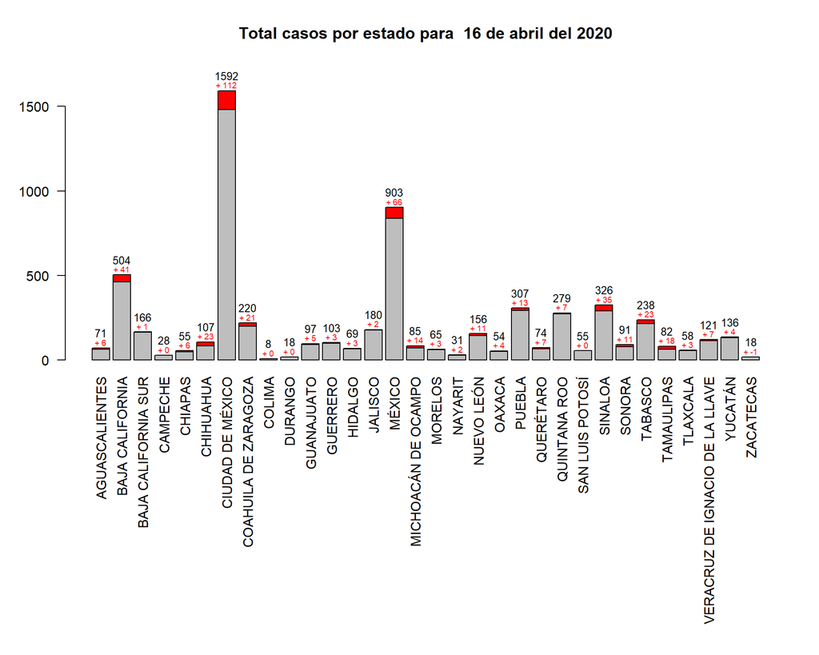

# Histogramas de registros positivos por estado (2)

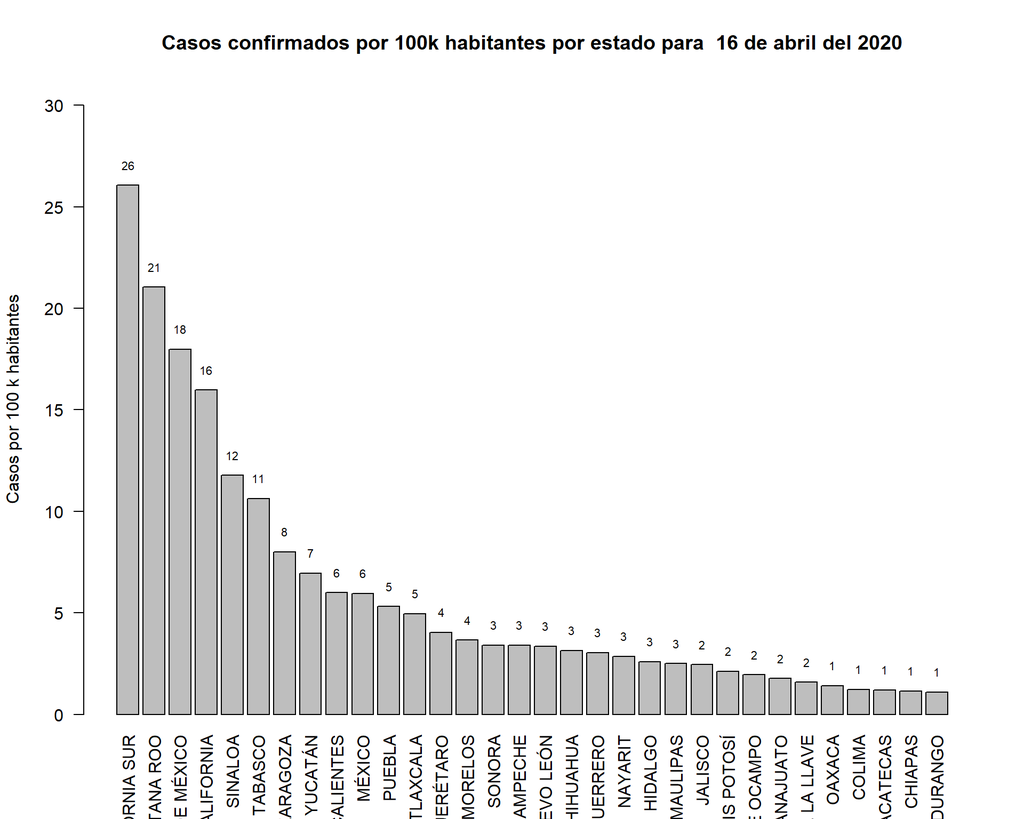

# Total de defunciones

### Total de defunciones registrados para 16 de abril del 2020: 486; aumento: 37.

## Resumen de defunciones por estado

Tabla. Defunciones por estado para 16 de abril del 2020

| ID | Estado | Total de defunciones | Defunciones para ayer | Aumento |
| --- | --- | --- | --- | --- |
| 1 | AGUASCALIENTES | 2 | 1 | 1 |
| 2 | BAJA CALIFORNIA | 30 | 28 | 2 |
| 3 | BAJA CALIFORNIA SUR | 6 | 6 | 0 |
| 4 | CAMPECHE | 2 | 1 | 1 |
| 7 | CHIAPAS | 3 | 3 | 0 |
| 8 | CHIHUAHUA | 23 | 20 | 3 |
| 9 | CIUDAD DE MÉXICO | 102 | 92 | 10 |
| 5 | COAHUILA DE ZARAGOZA | 16 | 13 | 3 |
| 10 | DURANGO | 4 | 4 | 0 |
| 11 | GUANAJUATO | 6 | 5 | 1 |
| 12 | GUERRERO | 9 | 8 | 1 |
| 13 | HIDALGO | 10 | 10 | 0 |
| 14 | JALISCO | 11 | 11 | 0 |
| 15 | MÉXICO | 55 | 51 | 4 |
| 16 | MICHOACÁN DE OCAMPO | 13 | 12 | 1 |
| 17 | MORELOS | 10 | 10 | 0 |
| 18 | NAYARIT | 5 | 5 | 0 |
| 19 | NUEVO LEÓN | 4 | 4 | 0 |
| 20 | OAXACA | 4 | 4 | 0 |
| 21 | PUEBLA | 34 | 33 | 1 |
| 22 | QUERÉTARO | 5 | 5 | 0 |
| 23 | QUINTANA ROO | 28 | 27 | 1 |
| 24 | SAN LUIS POTOSÍ | 4 | 4 | 0 |
| 25 | SINALOA | 40 | 38 | 2 |
| 26 | SONORA | 11 | 9 | 2 |
| 27 | TABASCO | 26 | 22 | 4 |
| 28 | TAMAULIPAS | 4 | 4 | 0 |
| 29 | TLAXCALA | 4 | 4 | 0 |
| 30 | VERACRUZ DE IGNACIO DE LA LLAVE | 6 | 6 | 0 |
| 31 | YUCATÁN | 7 | 7 | 0 |
| 32 | ZACATECAS | 2 | 2 | 0 |

# Histogramas de defunciones por estado

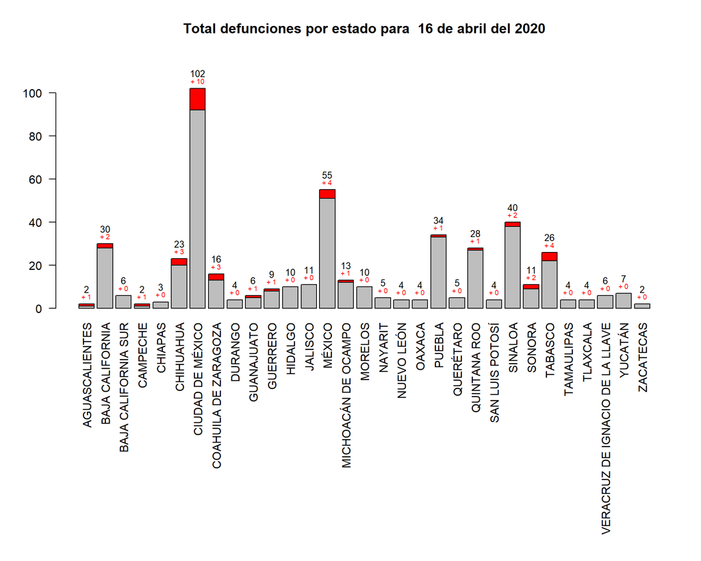

# Total de pruebas realizadas

### Total de pruebas con resultado negativo registrados para 16 de abril del 2020: 28598; aumento: 1726.

### Total de pruebas con resultado para 16 de abril del 2020: 34895; aumento: 2176

## Resumen de pruebas por estado

Tabla. Pruebas por estado para 16 de abril del 2020

| ID | Estado | Total de pruebas negativas | Nuevos negativos | Total de pruebas positivas | Nuevos positivos | Total de pruebas | Pruebas nuevas | % de positiovs | % de positivos en pruebas nuevas | Pruebas por 100k habitantes |
| --- | --- | --- | --- | --- | --- | --- | --- | --- | --- | --- |
| 1 | AGUASCALIENTES | 788 | 34 | 71 | 6 | 859 | 40 | 8.27 | 13.04 | 78.99 |
| 2 | BAJA CALIFORNIA | 918 | 46 | 504 | 41 | 1422 | 87 | 35.44 | 32.03 | 69.22 |
| 3 | BAJA CALIFORNIA SUR | 548 | 27 | 166 | 1 | 714 | 28 | 23.25 | 3.45 | 155.41 |
| 4 | CAMPECHE | 111 | 7 | 28 | 0 | 139 | 7 | 20.14 | 0.00 | 22.13 |
| 7 | CHIAPAS | 291 | 28 | 55 | 6 | 346 | 34 | 15.90 | 15.00 | 8.49 |
| 8 | CHIHUAHUA | 296 | 43 | 107 | 23 | 403 | 66 | 26.55 | 25.84 | 17.76 |
| 9 | CIUDAD DE MÉXICO | 5147 | 351 | 1592 | 112 | 6739 | 463 | 23.62 | 19.48 | 100.20 |
| 5 | COAHUILA DE ZARAGOZA | 1185 | 151 | 220 | 21 | 1405 | 172 | 15.66 | 10.88 | 84.67 |
| 6 | COLIMA | 98 | 1 | 8 | 0 | 106 | 1 | 7.55 | 0.00 | 20.91 |
| 10 | DURANGO | 306 | 26 | 18 | 0 | 324 | 26 | 5.56 | 0.00 | 25.29 |
| 11 | GUANAJUATO | 1667 | 26 | 97 | 5 | 1764 | 31 | 5.50 | 13.89 | 37.26 |
| 12 | GUERRERO | 327 | 5 | 103 | 3 | 430 | 8 | 23.95 | 27.27 | 17.09 |
| 13 | HIDALGO | 404 | 4 | 69 | 3 | 473 | 7 | 14.59 | 30.00 | 19.96 |
| 14 | JALISCO | 2708 | 83 | 180 | 2 | 2888 | 85 | 6.23 | 2.30 | 47.45 |
| 15 | MÉXICO | 2876 | 192 | 903 | 66 | 3779 | 258 | 23.90 | 20.37 | 34.79 |
| 16 | MICHOACÁN DE OCAMPO | 507 | 11 | 85 | 14 | 592 | 25 | 14.36 | 35.90 | 18.96 |
| 17 | MORELOS | 331 | 20 | 65 | 3 | 396 | 23 | 16.41 | 11.54 | 27.85 |
| 18 | NAYARIT | 192 | 10 | 31 | 2 | 223 | 12 | 13.90 | 14.29 | 25.81 |
| 19 | NUEVO LEÓN | 2072 | 252 | 156 | 11 | 2228 | 263 | 7.00 | 4.01 | 92.55 |
| 20 | OAXACA | 371 | 9 | 54 | 4 | 425 | 13 | 12.71 | 23.53 | 12.99 |
| 21 | PUEBLA | 893 | 59 | 307 | 13 | 1200 | 72 | 25.58 | 15.29 | 26.71 |
| 22 | QUERÉTARO | 461 | 16 | 74 | 7 | 535 | 23 | 13.83 | 23.33 | 33.43 |
| 23 | QUINTANA ROO | 475 | 9 | 279 | 7 | 754 | 16 | 37.00 | 30.43 | 71.29 |
| 24 | SAN LUIS POTOSÍ | 913 | 38 | 55 | 0 | 968 | 38 | 5.68 | 0.00 | 41.62 |
| 25 | SINALOA | 797 | 40 | 326 | 35 | 1123 | 75 | 29.03 | 31.82 | 52.24 |
| 26 | SONORA | 559 | 20 | 91 | 11 | 650 | 31 | 14.00 | 26.19 | 31.36 |
| 27 | TABASCO | 553 | 18 | 238 | 23 | 791 | 41 | 30.09 | 35.94 | 51.42 |
| 28 | TAMAULIPAS | 590 | 96 | 82 | 18 | 672 | 114 | 12.20 | 13.64 | 27.44 |
| 29 | TLAXCALA | 375 | 15 | 58 | 3 | 433 | 18 | 13.39 | 14.29 | 44.87 |
| 30 | VERACRUZ DE IGNACIO DE LA LLAVE | 994 | 38 | 121 | 7 | 1115 | 45 | 10.85 | 13.46 | 20.86 |
| 31 | YUCATÁN | 550 | 21 | 136 | 4 | 686 | 25 | 19.83 | 13.79 | 44.33 |
| 32 | ZACATECAS | 295 | 30 | 18 | -1 | 313 | 29 | 5.75 | -3.57 | 24.89 |

# Histogramas de pruebas por estado

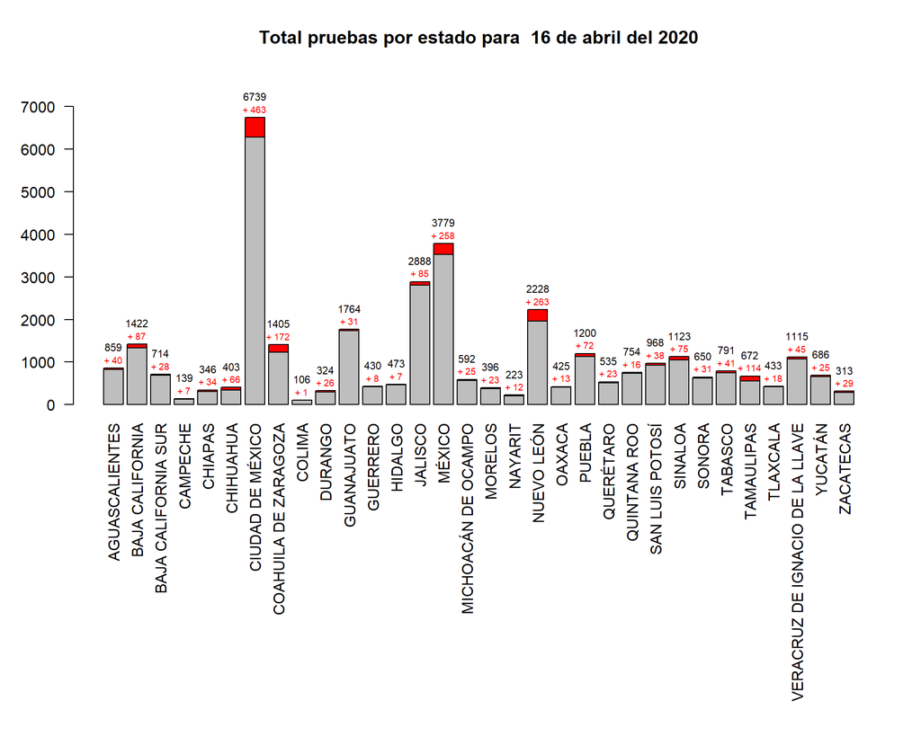

# Histogramas de pruebas por estado (2)

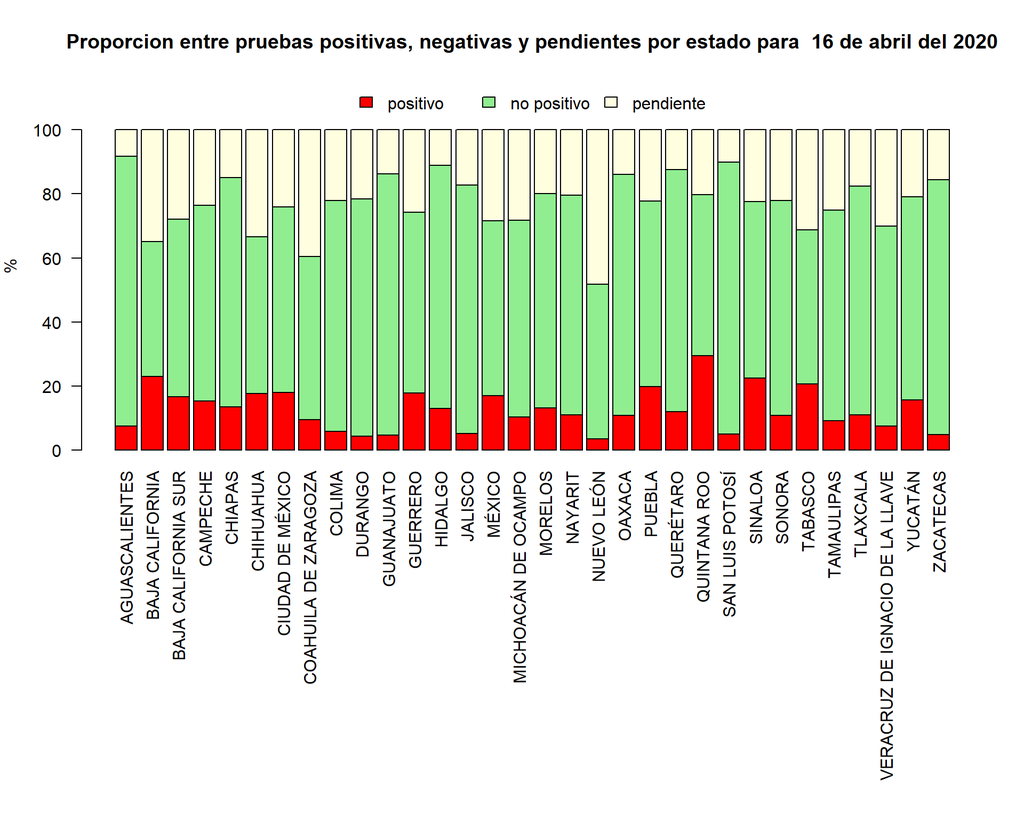

# Histogramas de pruebas por estado (3)

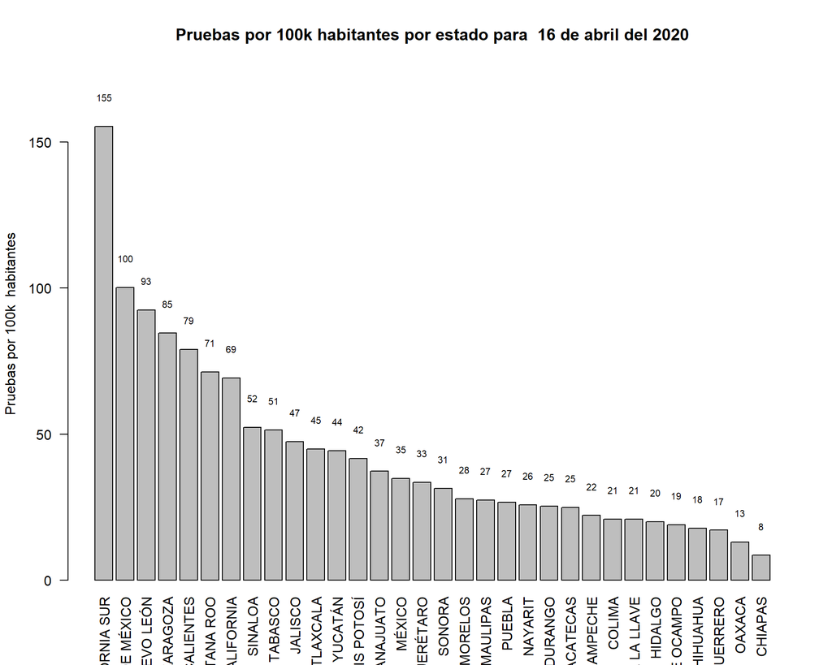

# Relación entre número de casos confirmados y numero de pruebas por estados de México

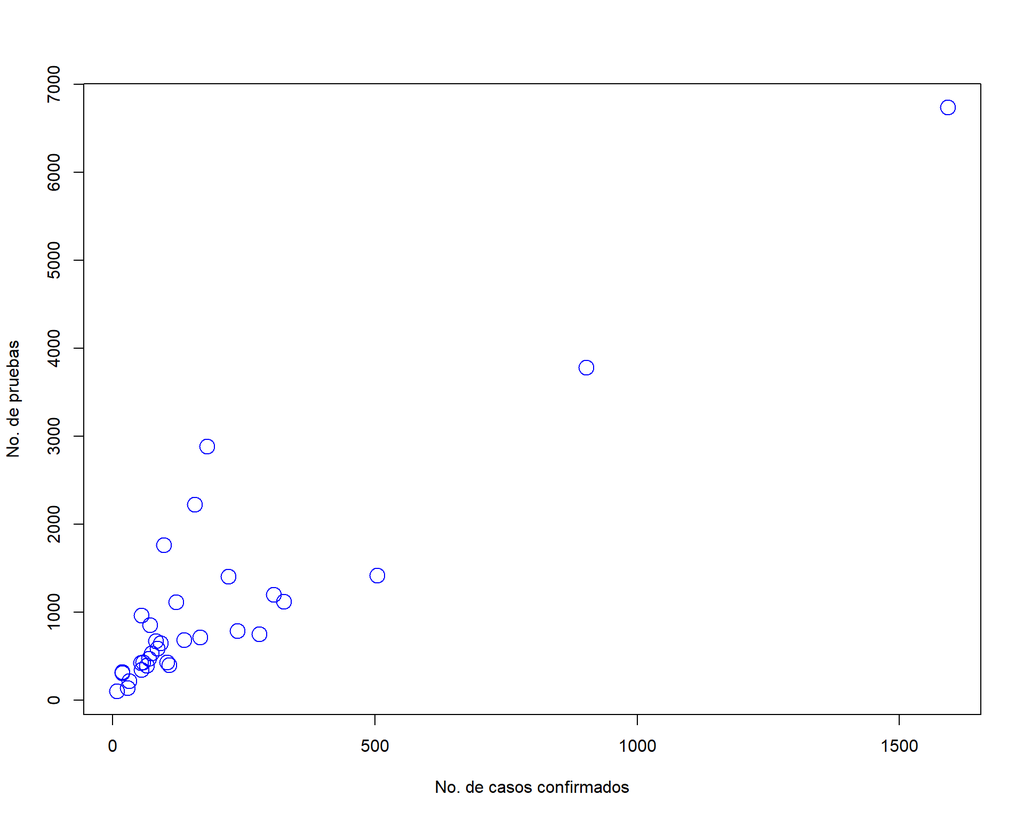

# Relación entre número de casos, numero de pruebas y porcentaje de pruebas positivas por estados de México

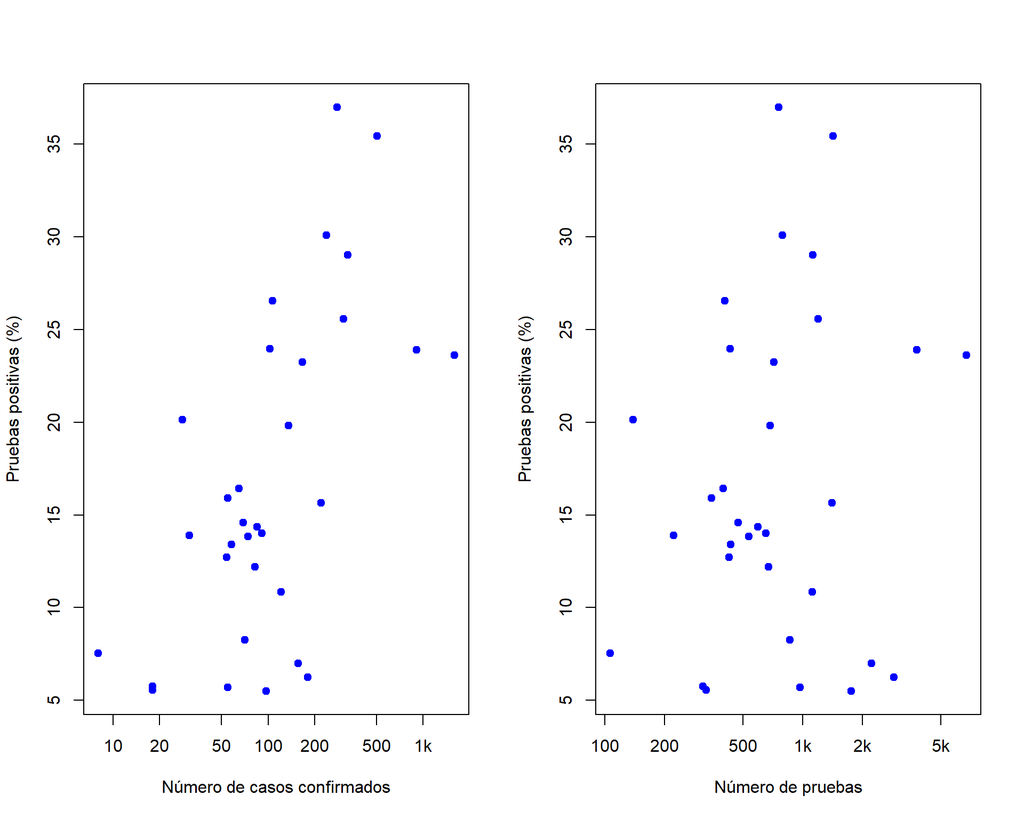

# Tabla de registros positivos por municipio

Tabla. Los cien municipios con mayór incidencia para 16 de abril del 2020

| Casos confirmados | Aumento casos | Casos por 100k habitantes | Defunciones | Aumento def. | Pruebas negativas | % de pruebas positivas | Pruebas por 100k habitantes | Localidad | Municipio | Estado |
| --- | --- | --- | --- | --- | --- | --- | --- | --- | --- | --- |
| 280 | 9 | 20.8 | 17 | 0 | 397 | 41.4 | 85.4 | Tijuana | TIJUANA | BC |
| 247 | 24 | 28.8 | 27 | 2 | 405 | 37.9 | 100.3 | Culiacán Rosales | CULIACÁN | SL |
| 212 | 19 | 11.7 | 19 | 3 | 595 | 26.3 | 62.2 | Iztapalapa | IZTAPALAPA | DF |
| 201 | 3 | 31.2 | 15 | 1 | 269 | 42.8 | 92.3 | Cancún | BENITO JUÁREZ | QR |
| 200 | 31 | 23.1 | 9 | 1 | 317 | 38.7 | 84.2 | Mexicali | MEXICALI | BC |
| 196 | 7 | 12.7 | 19 | 0 | 511 | 27.7 | 58.9 | Heroica Puebla de Zaragoza | PUEBLA | PL |
| 193 | 26 | 16.3 | 16 | 0 | 528 | 26.8 | 84.7 | Gustavo A. Madero | GUSTAVO A. MADERO | DF |
| 156 | 10 | 24.4 | 15 | 3 | 392 | 28.5 | 110.0 | Villahermosa | CENTRO | TC |
| 148 | 2 | 39.7 | 4 | 1 | 416 | 26.2 | 172.4 | Miguel Hidalgo | MIGUEL HIDALGO | DF |
| 134 | 12 | 20.6 | 6 | 2 | 378 | 26.2 | 103.4 | Tlalpan | TLALPAN | DF |
| 122 | 9 | 22.9 | 10 | 0 | 370 | 24.8 | 117.7 | Cuauhtémoc | CUAUHTÉMOC | DF |
| 118 | 1 | 16.2 | 12 | 0 | 414 | 22.2 | 98.1 | Álvaro Obregón | ÁLVARO OBREGÓN | DF |
| 116 | 0 | 77.6 | 2 | 0 | 258 | 31.0 | 337.2 | San José del Cabo | LOS CABOS | BS |
| 114 | 3 | 13.8 | 3 | 0 | 425 | 21.2 | 83.6 | Mérida | MÉRIDA | YN |
| 111 | 8 | 51.4 | 9 | 2 | 261 | 29.8 | 282.9 | Monclova | MONCLOVA | CL |
| 105 | 15 | 9.5 | 6 | 1 | 267 | 28.2 | 50.6 | Ciudad Nezahualcóyotl | NEZAHUALCÓYOTL | MC |
| 98 | 6 | 15.8 | 5 | 1 | 332 | 22.8 | 92.7 | Coyoacán | COYOACÁN | DF |
| 92 | 4 | 49.4 | 1 | 0 | 159 | 36.7 | 157.8 | Cuajimalpa de Morelos | CUAJIMALPA DE MORELOS | DF |
| 92 | 9 | 5.6 | 3 | 0 | 291 | 24.0 | 33.1 | Ecatepec de Morelos | ECATEPEC DE MORELOS | MC |
| 86 | 3 | 22.3 | 3 | 0 | 453 | 16.0 | 166.8 | Benito Juárez | BENITO JUÁREZ | DF |
| 78 | 4 | 9.4 | 4 | 1 | 275 | 22.1 | 57.7 | Naucalpan de Juárez | NAUCALPAN DE JUÁREZ | MC |
| 77 | 7 | 18.6 | 7 | 2 | 278 | 21.7 | 116.7 | Xochimilco | XOCHIMILCO | DF |
| 77 | 4 | 11.6 | 1 | 0 | 209 | 26.9 | 61.3 | Tlalnepantla | TLALNEPANTLA DE BAZ | MC |
| 75 | 4 | 18.1 | 3 | 0 | 261 | 22.3 | 108.5 | Azcapotzalco | AZCAPOTZALCO | DF |
| 75 | 5 | 17.4 | 5 | 0 | 243 | 23.6 | 94.2 | Venustiano Carranza | VENUSTIANO CARRANZA | DF |
| 73 | 19 | 5.5 | 22 | 3 | 149 | 32.9 | 25.9 | Juárez | JUÁREZ | CH |
| 66 | 8 | 17.2 | 5 | 1 | 189 | 25.9 | 98.6 | Iztacalco | IZTACALCO | DF |
| 64 | 2 | 4.3 | 3 | 0 | 772 | 7.7 | 69.1 | Guadalajara | GUADALAJARA | JC |
| 60 | 6 | 7.6 | 2 | 1 | 619 | 8.8 | 93.7 | Aguascalientes | AGUASCALIENTES | AS |
| 59 | 4 | 7.6 | 4 | 0 | 308 | 16.1 | 55.4 | Santiago de Querétaro | QUERÉTARO | QT |

[output cut: 70 more lines]

# Relación entre número de casos confirmados y numero de pruebas por municipios de México

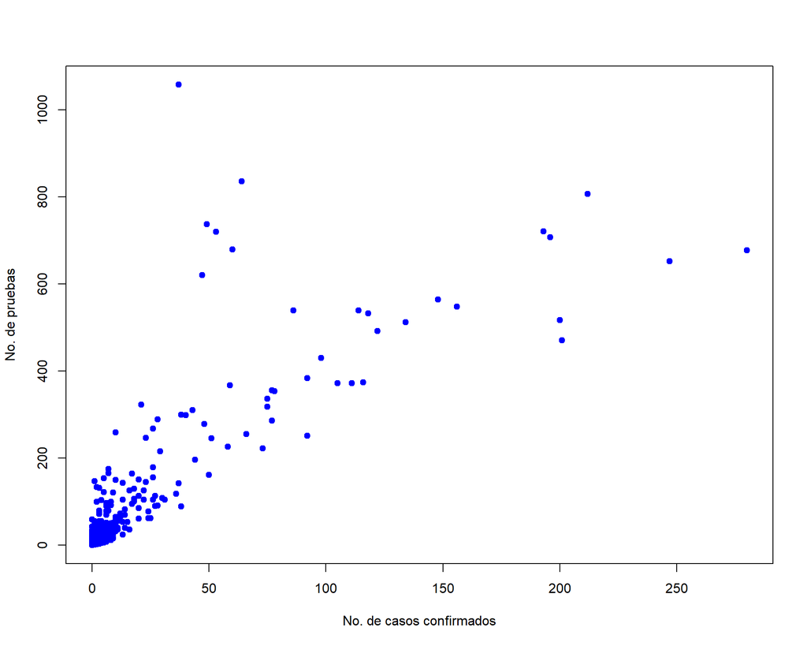

# Relación entre número de casos, numero de pruebas y porcentaje de pruebas positivas por municipios de México

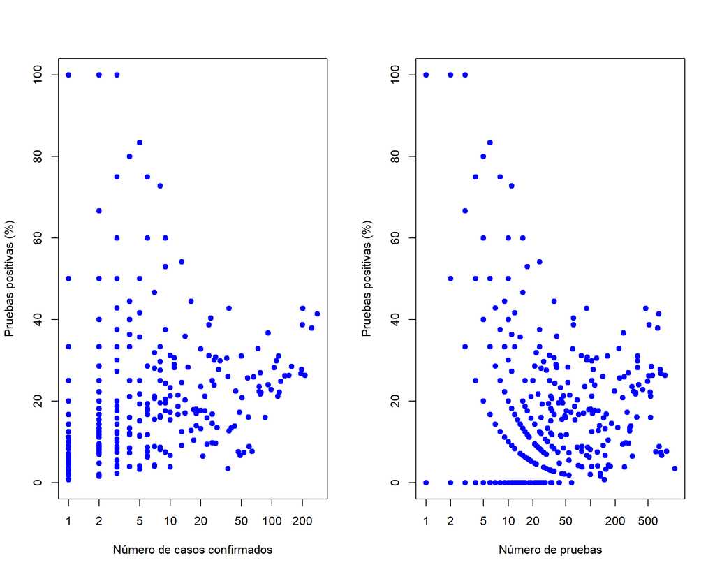

# Mapa de pruebas: número de pruebas para COVID-19 y % de positividad por municipio para 16 de abril del 2020

[interactive chart not shown]

# Mapa de casos confirmados de COVID-19 por municipio para 16 de abril del 2020

[interactive chart not shown]

# Mapa de defunciones por COVID-19 por municipio para 16 de abril del 2020

[interactive chart not shown]